# Atelier 6 : Regroupement, Résumé et Visualisation

Nom de l’auteur ici

15-08-2023

# Préparation des données

Pour commencer, **chargez les packages nécessaires** : {tidyverse}, {here}, {janitor}, et {esquisse}.

```r
pacman::p_load(tidyverse, esquisse, here, janitor)
```

Maintenant, **lisez le jeu de données dans R**. Le dataframe que vous importez devrait avoir 880 lignes et 21 colonnes. N’oubliez pas d’utiliser la fonction `here()` pour permettre à votre Rmd d’utiliser des chemins relatifs au projet.

```r
# Charger le dataset
tb_brut <- read_csv(here::here("data/inde_tuberculose.csv"))
```

Les noms de nombreuses colonnes dans ce jeu de données contiennent des espaces et des symboles (par exemple, `Delai initiation traitement (en jours)`), ce qui n’est pas pratique pour R.

Utilisez `janitor::clean_names()` pour donner à vos noms de variables un format propre et cohérent.

```r
# Nettoyer les noms de variables
tb_renomme <- janitor::clean_names(tb_brut)
```

**Point de contrôle** : Le dataframe devrait contenir 880 lignes et 21 colonnes. Les noms de colonnes/variables devraient maintenant être convertis en snake case. Vous pouvez exécuter `names(tb_renomme)` pour imprimer et vérifier les noms des variables.

Avant d’aller plus loin, examinons de plus près la variable `education` dans notre jeu de données :

```r
# count() vous permet de compter rapidement les valeurs uniques des variables
tb_renomme %>%
  count(education)
```

```
## # A tibble: 8 × 2
##   education                n
##   <chr>                <int>
## 1 Diplômé                 12
## 2 Diplômé et plus          3
## 3 Intermédiaire          191
## 4 Manquant                 6
## 5 Pas d'éducation        273
## 6 Primaire               221
## 7 Secondaire             122
## 8 Secondaire supérieur    52
```

Ici, nous voyons qu’il y a 8 valeurs uniques dans la variable `education`, nous informant du plus haut niveau d’éducation de chaque patient TB. Vous remarquerez que les niveaux d’éducation sont ordonnés alphabétiquement par défaut ! Cependant, dans ce cas, il serait plus utile de réordonner les niveaux d’éducation afin qu’ils soient disposés dans un ordre chronologique.

La structure de base de l’éducation en Inde peut être conceptualisée comme suit :

- Primaire -> Intermédiaire -> Secondaire -> Secondaire supérieur -> Diplômé -> Diplômé et plus

Utilisez `mutate()` et d’autres **fonctions d’aide** pour convertir la variable `education` en un facteur et définir les niveaux selon l’ordre ci-dessus.

```r
tb_propre <- tb_renomme %>%
  mutate(education = factor(education,
                             levels = c("Pas d'éducation",
                                        "Primaire",
                                        "Intermédiaire",
                                        "Secondaire",
                                        "Secondaire supérieur",
                                        "Diplômé",
                                        "Diplômé et plus",
                                        "Manquant")))
```

Nous utiliserons la variable `education` nouvellement transformée pour le regroupement, le résumé et la visualisation ci-dessous.

# Investigation des coûts de santé

## Étape 1 : Calculer une variable `cout_total`

Chaque enregistrement de patient note l’emplacement et le coût jusqu’à trois emplacements. Additionnez ces coûts (`premiere_visite_cout`, `deuxieme_visite_cout`, et `troisieme_visite_cout`) pour créer une variable `cout_total`.

```r
tb_propre2 <- tb_propre %>%
  mutate(cout_total = premiere_visite_cout + deuxieme_visite_cout + troisieme_visite_cout)
```

## Étape 2 : Résumer les coûts par groupe

- Le nombre de patients à chaque niveau d’éducation
- Le coût total moyen pour chaque niveau d’éducation

Stockez le tibble résultant dans un objet appelé `tableau_cout_edu`.

```r
tableau_cout_edu <- tb_propre2 %>%
  group_by(education) %>%
  summarise(nombre = n(),
            cout_moyen_total = mean(cout_total))
tableau_cout_edu
```

```
## # A tibble: 8 × 3
##   education            nombre cout_moyen_total
##   <fct>                 <int>            <dbl>
## 1 Pas d'éducation         273            1527.
## 2 Primaire                221            1544.
## 3 Intermédiaire           191            1989.
## 4 Secondaire              122            2135
## 5 Secondaire supérieur     52            1869.
## 6 Diplômé                  12            3467.
## 7 Diplômé et plus           3            2267.
## 8 Manquant                  6            1767.
```

Réordonnez les lignes du tableau récapitulatif du plus haut au plus bas coût moyen.

```r
tableau_cout_edu %>%
  arrange(desc(cout_moyen_total), .by_group = TRUE)
```

```
## # A tibble: 8 × 3
##   education            nombre cout_moyen_total
##   <fct>                 <int>            <dbl>
## 1 Diplômé                  12            3467.
## 2 Diplômé et plus           3            2267.
## 3 Secondaire              122            2135
## 4 Intermédiaire           191            1989.
## 5 Secondaire supérieur     52            1869.
## 6 Manquant                  6            1767.
## 7 Primaire                221            1544.
## 8 Pas d'éducation         273            1527.
```

Ici, nous pouvons voir que les patients TB dans cette étude avec peu ou pas de scolarisation dépensent généralement moins d’argent pour le traitement que les diplômés. Ces données peuvent être mieux communiquées avec un graphique.

# Visualiser les données avec {esquisse}

En utilisant `esquisser()` et le tableau récapitulatif des coûts que vous avez créé plus tôt, créez un graphique en barres des coûts moyens, par niveau d’éducation.

```r
# esquisser(tableau_cout_edu)

ggplot(tableau_cout_edu) +
 aes(x = education, y = cout_moyen_total, fill = cout_moyen_total) +
 geom_col() +
 scale_fill_gradient() +
 theme_minimal() +
 theme(legend.position = "none")
```

[output not shown]

Lorsque vous êtes satisfait de votre graphique, utilisez `ggsave()` pour sauvegarder votre graphique dans un nouveau dossier appelé “outputs”. N’oubliez pas de spécifier le type de fichier et les dimensions de l’image que vous souhaitez exporter.

```r
# Sauvegardez votre/vos graphique(s)
ggsave(here("outputs/cout_educ_bar.jpg"))
```

# Conclusion

C’est tout pour cet atelier ! Nous choisirons 2-3 personnes pour présenter votre travail pendant l’atelier. Si vous souhaitez partager vos résultats avec la classe, veuillez le faire savoir à un instructeur.

# Défi Bonus (Optionnel et non noté)

Si vous terminez tôt et que vous avez du temps supplémentaire, vous pouvez explorer et transformer davantage le jeu de données.

Nous pouvons examiner deux types d’établissements de santé dans le jeu de données : privé et public (gouvernemental).

```r
tb_propre2 %>% count(premiere_visite_emplacement)
```

```
## # A tibble: 9 × 2
##   premiere_visite_emplacement     n
##   <chr>                       <int>
## 1 GH                            186
## 2 Other                           4
## 3 PHC                            76
## 4 Pvt. clini                    162
## 5 Pvt. docto                    256
## 6 Pvt. hospi                    148
## 7 T.Govt                         14
## 8 T.Pvt                           3
## 9 Tambram sanatorium             31
```

Note : PHC = centre de santé primaire, GH = hôpital gouvernemental, etc.

## Comparaison des retards dans les établissements de santé publics et privés

Créons une nouvelle variable indiquant si un lieu de soins de santé est privé ou public. Nous pouvons le faire en utilisant la fonction `str_detect()` du package `{stringr}` de tidyverse.

```r
tb_propre3 <- tb_propre2 %>%
  mutate(type_premiere_visite = case_when(
    str_detect(premiere_visite_emplacement, "Pvt") ~ "Privé",
    TRUE ~ "Public"))
```

Inspectez la nouvelle variable dans `tb_propre3`.

Votre mission pour ce défi est de résumer les retards dans le traitement et de comparer la durée des retards entre les établissements de santé privés et publics.

```r
tableau_retard <- tb_propre3 %>%
  group_by(type_premiere_visite) %>%
  summarise(
    retard_moyen_hs_jours = mean(retard_sys_sante_en_jours,
                                 na.rm = T),
    retard_moyen_ti_jours = mean(delai_initiation_traitement_en_jours,
                                 na.rm = T)) %>%
  arrange(desc(retard_moyen_hs_jours), .by_group = TRUE)

tableau_retard
```

```
## # A tibble: 2 × 3
##   type_premiere_visite retard_moyen_hs_jours retard_moyen_ti_jours
##   <chr>                                <dbl>                 <dbl>
## 1 Privé                                 34.1                  8.43
## 2 Public                                25.5                  9.27
```

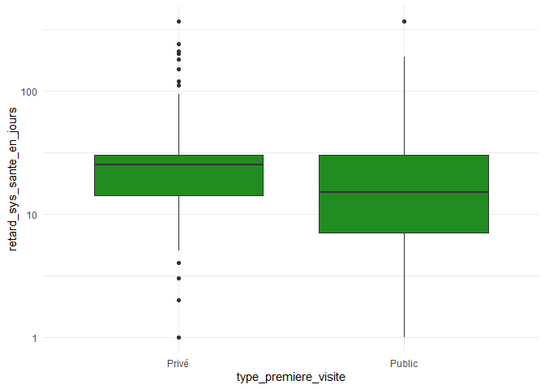

```r
ggplot(tb_propre3) +
  aes(x = retard_sys_sante_en_jours, y = type_premiere_visite) +
  geom_boxplot(fill = "forestgreen") +
  theme_minimal() +
  coord_flip() +
  scale_x_log10()
```